# regressao-linear

## Aprendizado de Máquina I

### Hugo Tremonte de Carvalho

#### `hugo@dme.ufrj.br`

### 02 - Regressão Linear

# Formulação matemática do problema de regressão linear

## Formulação matemática

- $Y \in \mathbb{R}$ variável de resposta
- $\mathbf{X} = (X_1, \dots, X_p) \in \mathbb{R}^p$ conjunto de $p$ preditores para $Y$
- Forma geral da relação entre $\mathbf{X}$ e $Y$:
  $$Y = r(\mathbf{X}) + \varepsilon, ~~ \text{com}$$
  $$r(\mathbf{x}) = \beta_0 + \sum_{i = 1}^{p} \beta_i x_i = \sum_{i = 0}^{p} \beta_i x_i = \mathbf{x}^{\intercal}\boldsymbol{\beta} = \boldsymbol{\beta}^{\intercal}\mathbf{x}$$
  definindo $x_0 = 1$ e usando a notação vetorial

## Formulação matemática

- **Objetivos**: Estimar $\beta_0, \dots, \beta_p$ a partir de um conjunto de observações $(\mathbf{x}_i, y_i)_{i = 1, \dots, n}$, bem como aferir a *qualidade* de tal estimativa
- $Y$ quantitativa: problema de *regressão*

## Um exemplo

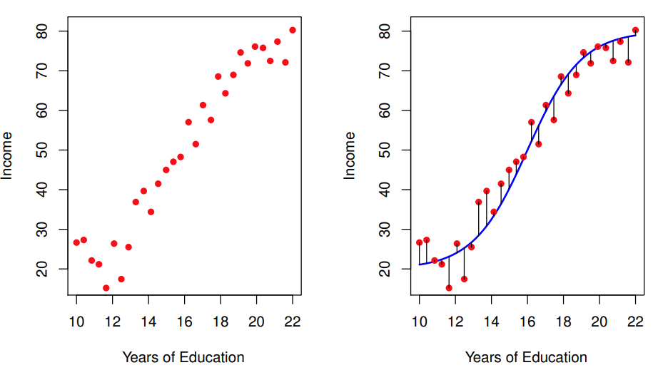

Figura 2.2 de [ITSL]

## Algumas observações

- $x_i$ não é necessariamente a $i$-ésima variável original
  - Criar novas covariáveis como funções das originais, por exemplo: $x_i^2$, $x_i x_j$, etc.
- Notação vetorial
  - $\mathbf{u}$ sempre denota um vetor *coluna*
  - $\mathbf{u}^{\intercal}$ denota o transposto do vetor $\mathbf{u}$
  - $\mathbf{u}^{\intercal}\mathbf{v}$ denota o produto escalar entre $\mathbf{u}$ e $\mathbf{v}$ (notação equivalente a $\langle \mathbf{u}, \mathbf{v} \rangle$)
    - Apenas para vetores reais!

# O método dos mínimos quadrados

## Observação preliminar

- A matriz $\mathbb{X}$ contém os dados observados:
  $$\mathbb{X} = \begin{pmatrix} - ~\mathbf{x}_1^{\intercal} ~ - \\ - ~\mathbf{x}_2^{\intercal} ~ - \\ \vdots \\ - ~ \mathbf{x}_n^{\intercal} ~ -\end{pmatrix}$$

## O método dos mínimos quadrados

- Uma forma de estimar os coeficientes $\boldsymbol{\beta}$ da regressão linear é utilizando o método dos mínimos quadrados, isto é,
  $$\hat{\boldsymbol{\beta}} = \mathrm{arg}\min_{\boldsymbol{\beta}} \sum_{i = 1}^{n} (y_i - \mathbf{x}_i^{\intercal}\boldsymbol{\beta})^2 = \|\mathbf{y} - \mathbb{X}\boldsymbol{\beta}\|^2$$
- A solução para esse problema é dada por
  $$\hat{\boldsymbol{\beta}} = (\mathbb{X}^{\intercal}\mathbb{X})^{-1}\mathbb{X}\mathbf{y}$$
- A função de regressão é estimada por $g(\mathbf{x}) = \hat{\boldsymbol{\beta}}^{\intercal}\mathbf{x}$

## Além da linearidade

- Se a função $r$ não for linear, o estimador $\hat{\boldsymbol{\beta}}$ converge para o *melhor preditor linear*, e o risco associado a $\hat{\boldsymbol{\beta}}$ também converge para o risco associado ao melhor preditor linear
- **Teorema** (Teo. 2, Sec. 2.1.1 [AME]): Seja $\boldsymbol{\beta}_\ast$ o melhor preditor linear ($\arg\min_{\boldsymbol{\beta}} \mathbb{E} \left[ \left( Y - \boldsymbol{\beta}^\intercal \mathbf{X} \right)^2 \right]$), e seja $\hat{\boldsymbol{\beta}}$ o estimador de mínimos quadrados. Assuma que $\Sigma = \mathbb{E}[\mathbf{X}\mathbf{X}^\intercal]$ está bem definida. Então
  $$\hat{\boldsymbol{\beta}} \xrightarrow[n \to \infty]{p} \boldsymbol{\beta}_\ast
  \quad \text{e} \quad
  R\!\left( g_{\hat{\boldsymbol{\beta}}} \right) \xrightarrow[n \to \infty]{p} R\!\left( g_{\boldsymbol{\beta}_\ast} \right).$$

# Regularização

## Motivação

- O estimador de mínimos quadrados, quando há muitas covariáveis (isto é, $p$ é grande), pode possuir baixo desempenho
- Muitos parâmetros a serem estimados e, portanto, a função de regressão estimada apresenta baixo poder preditivo
- Em outras palavras, a variância do estimador resultante é alta, pois muitos parâmetros precisam ser estimados
- Como resolver esse problema?

## Penalização

- Mudar a função-objetivo do problema de mínimos quadrados:
  $$\|\mathbf{y} - \mathbb{X}\boldsymbol{\beta}\|^2 + \mathcal{P}(\boldsymbol{\beta})$$
  - $\mathcal{P}_2(\boldsymbol{\beta}) = \lambda\sum_{j = 1}^p \beta_j^2$ – regressão *ridge*
  - $\mathcal{P}_1(\boldsymbol{\beta}) = \lambda\sum_{j = 1}^p |\beta_j|$ – regressão *lasso* (*least absolute shrinkage and selection operator*)
  - $\mathcal{P}_0(\boldsymbol{\beta}) = \lambda\sum_{j = 1}^p \mathbf{1}(\beta_j \neq 0)$, $\mathbf{1}$ é a função indicadora
- Hiperparâmetro $\lambda$ escolhido por validação cruzada

## Algumas coisas

- Note que $\beta_0$ **nunca** é penalizado – intercepto
- $\mathcal{P}_0$ leva a um problema de otimização intratável: considerar todas as $2^p$ possibilidades de $\beta_j$’s não nulos $\Rightarrow$ resolver $2^p$ problemas de mínimos quadrados
- $\mathcal{P}_2$ tem solução analítica: $\hat{\boldsymbol{\beta}}_{R, \lambda} = (\mathbb{X}^{\intercal}\mathbb{X} + \lambda\mathbb{I})^{-1}\mathbb{X}\mathbf{y}$, onde $\mathbb{I}$ é a matriz identidade de tamanho compatível
  - $\hat{\boldsymbol{\beta}}_{R, \lambda}$ possui, em geral, entradas menores (em módulo) que $\hat{\boldsymbol{\beta}}$, a depender da escolha de $\lambda$

## O lasso

- A regressão lasso *não* tem solução analítica
- *Relaxamento convexo* da regressão com penalização $\mathcal{P}_0$
- Tende a gerar estimativas *esparsas* (muitas entradas iguais a zero), a depender da escolha de $\lambda$
  - Porém, isso **não** é um fato óbvio nem intuitivo!
- Existem algoritmos para calcular rapidamente $\hat{\boldsymbol{\beta}}_{L, \lambda}$ para todos os valores de $\lambda$
  - Ainda assim, selecionaremos $\lambda$ por validação cruzada

## Esparsidade do lasso

- Em um cenário simplificado, é possível encontrar uma solução analítica do lasso
- Assuma que a matriz $\mathbb{X}$ é *ortonormal*, ou seja, $\mathbb{X}^\intercal\mathbb{X} = \mathbb{I}$
- Sejam $\hat{\beta}_j^{LS}$ a $j$-ésima entrada do estimador proveniente do problema de regressão linear sem penalização (LS de *least squares*) e $\hat{\beta}_j^{L}$ a $j$-ésima entrada do estimador proveniente do lasso. Então:
  $$\hat{\beta}_j^{L} = \mathrm{sinal}(\hat{\beta}_j^{LS})\max(|\hat{\beta}_j^{LS}| - \lambda, 0)$$

## Uma intuição visual

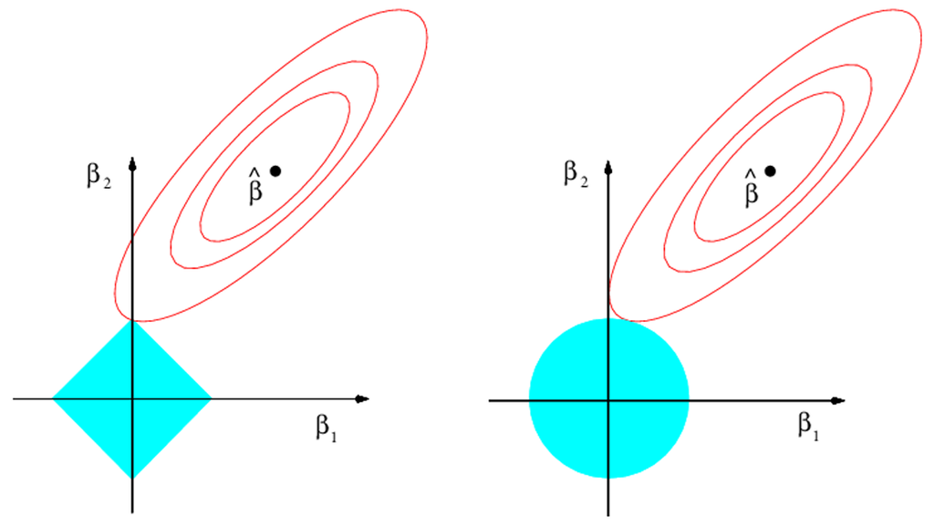

Figura 6.7 de [ITSL]

## Um questionamento

- Como se aplica o balanço entre viés e variância para as regressões com penalização?